# IMDB Analysis

2022-09-20

# Analysis of movies- IMDB dataset

In this part I will look at a subset sample of movies, taken from the [Kaggle IMDB 5000 movie dataset](https://www.kaggle.com/carolzhangdc/imdb-5000-movie-dataset)

```r
movies <- read_csv(here::here("data", "movies.csv"))
```

There are 11 variables in this dataset, 3 of them are characters and 8 are numeric: `title`, `genre`, `director`, `year`, and `duration`, the rest of the variables are as follows:

- `gross` : The gross earnings in the US box office, not adjusted for inflation
- `budget`: The movie’s budget
- `cast_facebook_likes`: the number of facebook likes cast members received
- `votes`: the number of people who voted for (or rated) the movie in IMDB
- `reviews`: the number of reviews for that movie
- `rating`: IMDB average rating

## Before begining my work

Before I dig deep in the dataset, I want to firstly check if my dataset is “clean”

```r
# If there is NA.
print("Number of missing values: ")
```

```
## [1] "Number of missing values: "
```

```r
sum(is.na(movies)) # Fortunately, there is no NA.
```

```
## [1] 0
```

```r
# If there is duplicate values
print("Number of duplicate values: ")
```

```
## [1] "Number of duplicate values: "
```

```r
sum(duplicated(movies)) # no, there are no duplicate entries
```

```
## [1] 0
```

It seems that the data is tidy. Let’s begin to work on it!

## Explore the data

### Genre

I first count the number of movies on various subjects, and comedies and action movies are the most.

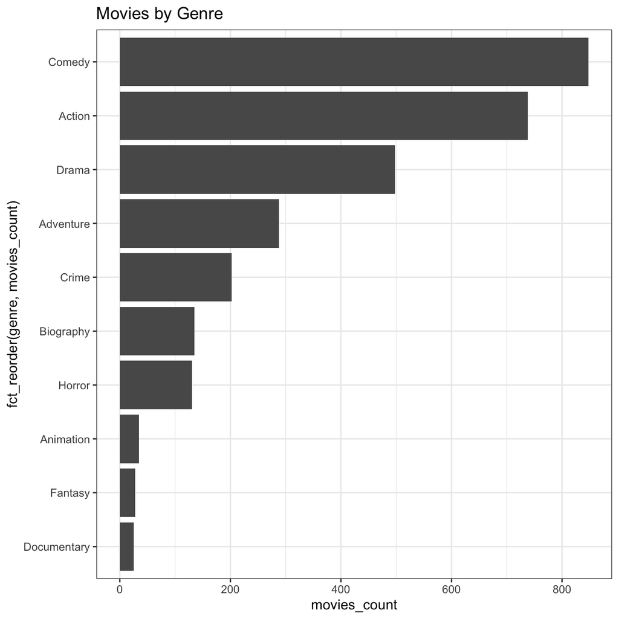

```r
movies_count <- movies %>%  # assigning a variable
  group_by(genre) %>% # grouping the movie dataset by genre
  summarize(movies_count = n()) %>%  # using the summarise function to count the no of movies in each genre
  slice_max(order_by = movies_count, n = 10) %>%
  ggplot(aes(x = movies_count,
             y = fct_reorder(genre, movies_count))) +
  geom_col() +
  theme_bw() +
  labs(title = "Movies by Genre")

movies_count
```

Then I also want to look at the gross and budget of these movies.

- Produce a table with the average gross earning and budget (`gross` and `budget`) by genre. Calculate a variable `return_on_budget` which shows how many $ did a movie make at the box office for each $ of its budget. Ranked genres by this `return_on_budget` in descending order.

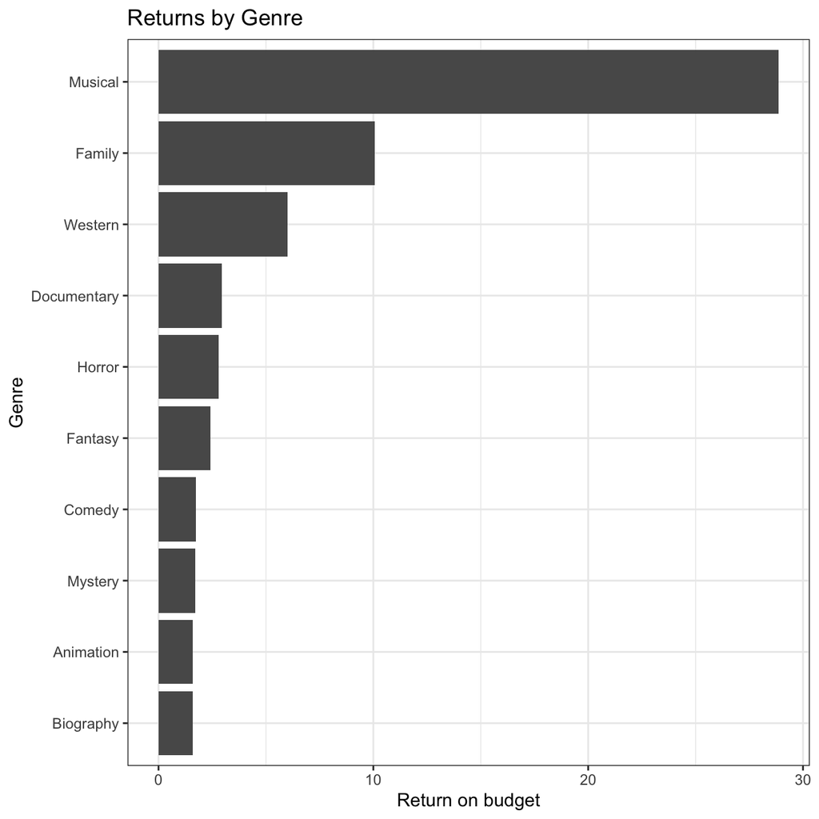

```r
avg_gross_earning_plot <- movies %>%
  group_by(genre) %>%
  summarize(avg_gross_earning = mean(gross),
            avg_budget = mean(budget),
            return_on_budget = avg_gross_earning/avg_budget) %>%
  slice_max(order_by = return_on_budget, n = 10) %>%
  ggplot(aes(x = return_on_budget,
             y = fct_reorder(genre, return_on_budget))) +
  geom_col() +
  theme_bw() +
  labs(title = "Returns by Genre",
       x = "Return on budget",
       y = "Genre")

avg_gross_earning_plot
```

In terms of return on budget, we can see that musical genre has the highest return. That is partly because low budget is needed for such kind of movies - you don’t need many expensive props (eg. cars, skyscrapers), and not too much money to spend in post production to get fancy special effects.

### Directors

Let’s take a look about what the top 15 directors who have created the highest gross revenue in the box office.

```r
movies %>%
    group_by(director) %>%
    summarize(total_gross_amount = sum(gross),
        mean_gross_amount = mean(gross),
        median_gross_amount = median(gross),
        standard_deviation_gross_amount = sd(gross)) %>%
    slice_max(order_by = total_gross_amount, n=15)
```

```
## # A tibble: 15 × 5
##    director          total_gross_amount mean_gross_amount median_gross…¹ stand…²
##    <chr>                          <dbl>             <dbl>          <dbl>   <dbl>
##  1 Steven Spielberg          4014061704        174524422.     164435221   1.01e8
##  2 Michael Bay               2231242537        171634041.     138396624   1.27e8
##  3 Tim Burton                2071275480        129454718.      76519172   1.09e8
##  4 Sam Raimi                 2014600898        201460090.     234903076   1.62e8
##  5 James Cameron             1909725910        318287652.     175562880.  3.09e8
##  6 Christopher Nolan         1813227576        226653447      196667606.  1.87e8
##  7 George Lucas              1741418480        348283696      380262555   1.46e8
##  8 Robert Zemeckis           1619309108        124562239.     100853835   9.13e7
##  9 Clint Eastwood            1378321100         72543216.      46700000   7.55e7
## 10 Francis Lawrence          1358501971        271700394.     281666058   1.35e8
## 11 Ron Howard                1335988092        111332341      101587923   8.19e7
## 12 Gore Verbinski            1329600995        189942999.     123207194   1.54e8
## 13 Andrew Adamson            1137446920        284361730      279680930.  1.21e8
## 14 Shawn Levy                1129750988        102704635.      85463309   6.55e7
## 15 Ridley Scott              1128857598         80632686.      47775715   6.88e7
## # … with abbreviated variable names ¹median_gross_amount,
## #   ²standard_deviation_gross_amount
```

Are the differences in ratings in line with differences in gross? Let’s have a look.

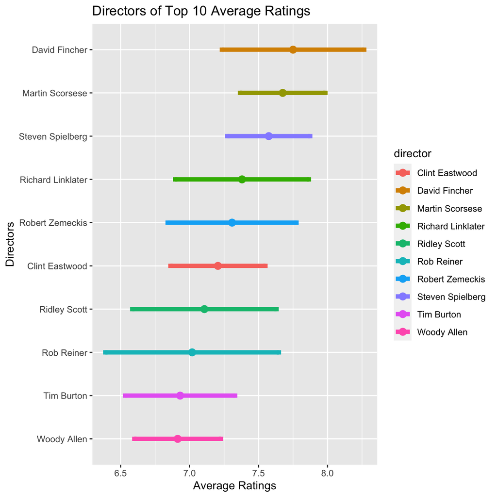

```r
ci_interval <- movies %>%
  group_by(director) %>%
  summarize(avg = mean(rating),
            sd =sd(rating),
            count = n(),
            se = sd / sqrt(count),
            t_critical = qt(0.975, count-1),
            lower = avg - se *t_critical,
            upper = avg + se *t_critical) %>%
  filter(count >= 10) %>%
  slice_max(order_by = avg, n = 10) %>%
  ggplot(aes(x = avg, y = fct_reorder(director, avg))) +
  geom_point(aes(x = avg, color = director), size = 3) +
  geom_errorbar(aes(xmin = lower, xmax = upper, color = director), width = 0.1, size = 2) +
  labs(title = "Directors of Top 10 Average Ratings",
       x = "Average Ratings",
       y = "Directors")

ci_interval
```